# Introduction

- This projects aims to apply [CoSTA](https://bmcbioinformatics.biomedcentral.com/articles/10.1186/s12859-021-04314-1) pipeline on Visium datasets. Also modify CoSTA architecture to include transformer layers.
- Here we've used the 10X Genomics Visium 4 human prostate sample downloaded from here 10X Genomics Datasets.
- Samples were initially analyzed using Seurat V4 spaital data analysis pipeline Here. `creating_gene_exp_images.Rmd` notebook was used to generate the spatial gene expression images from the samples. Briefly, each dataset was imported using `Load10X_Spatial` function, then normalized using `SCTransform()` function, then filtered for top highly variable 3000 genes, then gene expression images (200*200) were generated using SpatialFeaturePlot()`.
- Images were processed to (85*85) grayscale images to make computational faster, and all images were concatenated in (3000,1,85,85) array.

# Importing modules

```python
import numpy as np
import pandas as pd
import seaborn as sns
import torch
import model
import utils
import train
import umap.umap_ as umap
import umap.plot
from importlib import reload
from PIL import Image
import matplotlib.pyplot as plt
from os import listdir
from os.path import isfile, join
import re
```

```python
reload(model)
reload(utils)
reload(train)
```

```
<module 'train' from '/nfs/turbo/dcmb-class/bioinf593/sec001/hossiny/Bioinf593_project/notebooks/train.py'>
```

# Analyzing Acinar Cell Carcinoma Sample

## Loading the processing images array

Here We're loading the spatial gene expression arrays generated in the `converting_images_to_np_array` notebook. We'll be using the 85*85 images array. Then we're plotting the frequency of the mean pixel intensity of the genes images to filter out images with mostly background. We're setting the cut-off to 20. Then we're normalizng the pixels intensity values across all images as described in the paper.

```python
h,w = 85,85
dataset = np.load("../results/HVGeneExpArrays_85/acinar_cell_carcinoma.npy")
genes = listdir("../results/HVGeneExpImgs/acinar_cell_carcinoma/")
genes = [re.sub('.jpeg$', '', gene) for gene in genes]
dataset = dataset.reshape(dataset.shape[0],1,h,w)
```

```
(0.0, 920.0)
```

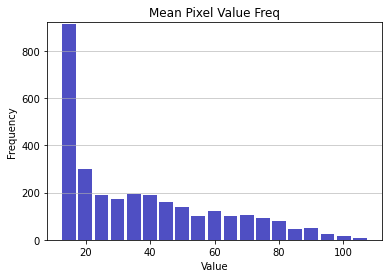

```python
n, bins, patches = plt.hist(x= np.mean(dataset.reshape(dataset.shape[0],85*85), axis =1), bins='auto', color='#0504aa',
                            alpha=0.7, rwidth=0.85)
plt.grid(axis='y', alpha=0.75)
plt.xlabel('Value')
plt.ylabel('Frequency')
plt.title('Mean Pixel Value Freq')
maxfreq = n.max()
plt.ylim(ymax=np.ceil(maxfreq / 10) * 10 if maxfreq % 10 else maxfreq + 10)
```

```python
fil = np.where(dataset.mean(axis = (1,2,3)) > 20)[0].tolist()
dataset = dataset[fil]
genes = np.array(genes)[fil].tolist()
```

```python
dataset = utils.normalize(expr= dataset, genes = genes, h = h, w = w)
```

```python
# normal_reshaped = normal.reshape(normal.shape[0], normal.shape[2]*normal.shape[3])

#var = pd.DataFrame({"var" : normal.reshape(normal.shape[0], normal.shape[2]*normal.shape[3]).var(axis=1)})

# cv =  lambda x: np.std(x) / np.mean(x)
# cov = pd.DataFrame({'cov':
#                     np.apply_along_axis(cv, axis=1, arr=normal_reshaped)})
# cov.index = genes
# cov.sort_values(by = ['cov'], ascending= False, inplace= True)

# HVG = cov.iloc[0:200,].index.tolist()
# HVG_indices = [genes.index(gene) for gene in HVG]
# normal_HVG = normal.take(HVG_indices, axis = 0)
# normal_HVG = normalize(expr= normal_HVG, genes= HVG)
```

## Loading model

Here we're using the same model described in the paper. We only changed the stride of the first layer to 1 as this showed superior performance

```python
net = model.ConvNet85()
net.apply(utils.weights_init)
device = torch.device("cuda" if torch.cuda.is_available() else "cpu")
net
```

```
ConvNet85(
  (layer1): Sequential(
    (0): Conv2d(1, 128, kernel_size=(11, 11), stride=(1, 1), padding=(1, 1))
    (1): BatchNorm2d(128, eps=1e-05, momentum=0.1, affine=True, track_running_stats=True)
    (2): ReLU()
    (3): MaxPool2d(kernel_size=2, stride=2, padding=0, dilation=1, ceil_mode=False)
  )
  (layer2): Sequential(
    (0): Conv2d(128, 128, kernel_size=(7, 7), stride=(1, 1), padding=(1, 1))
    (1): BatchNorm2d(128, eps=1e-05, momentum=0.1, affine=True, track_running_stats=True)
    (2): ReLU()
    (3): MaxPool2d(kernel_size=2, stride=2, padding=0, dilation=1, ceil_mode=False)
  )
  (layer3): Sequential(
    (0): Conv2d(128, 128, kernel_size=(5, 5), stride=(1, 1), padding=(1, 1))
    (1): BatchNorm2d(128, eps=1e-05, momentum=0.1, affine=True, track_running_stats=True)
    (2): ReLU()
    (3): MaxPool2d(kernel_size=2, stride=2, padding=0, dilation=1, ceil_mode=False)
  )
  (dropout): Dropout(p=0.5, inplace=False)
  (fc2): Linear(in_features=6272, out_features=10, bias=True)
)
```

## Gene pseudolabels before training

```python
##visualization without training
import umap.umap_ as umap
X_all_tensor = torch.tensor(dataset).float()
y_pred = net.forward_feature(X_all_tensor)
y_pred = torch.Tensor.cpu(y_pred).detach().numpy()
au_tar, y_label, embedding = utils.evaluation(y_pred,n_neighbors=5,min_dist=0.0,
                                        num_cluster=10,cluster_method='GMM')
original = y_label.copy()
embedding = umap.UMAP(n_neighbors=5, min_dist=0.0, n_components=2,
                      metric='correlation').fit_transform(y_pred)
```

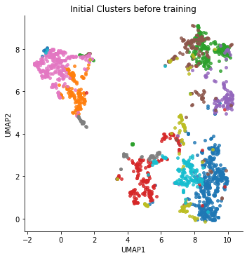

```python
embedding_df = pd.DataFrame(embedding)
embedding_df.columns=['UMAP1','UMAP2']
embedding_df["Proton"]=original

plt.figure(figsize=(10,10))
f=sns.lmplot(x='UMAP1', y='UMAP2',data=embedding_df,hue="Proton",
             fit_reg=False,legend=False,scatter_kws={'s':15})

plt.title("Initial Clusters before training")
plt.savefig("../results/figures/Initial_clusters_acinar_cell_carci.png", format = 'png', bbox_inches="tight", dpi = 200)
```

```python
# Interacitve UMAP
import umap.umap_ as umap
embedding = umap.UMAP(n_neighbors=15, min_dist=0.3, n_components=2,
                      metric='correlation').fit(y_pred)
import umap.plot
hover_data = pd.DataFrame(
{'cluster':np.argmax(au_tar, axis = 1),
 'Gene': genes,
 'Index': range(dataset.shape[0])})
p = umap.plot.interactive(embedding, labels= np.argmax(au_tar, axis = 1), hover_data=hover_data, point_size=5,color_key_cmap='Paired', background='black')
umap.plot.show(p)
```

## Training Model

```python
y_pred_acinar, au_tar_acinar, NMI_history_acinar = train.train_costa(net = net, expr_array = dataset, num_epoch = 50, batch_size = 256, t1 = 0.8, t2 = 1.2, cluster_method= 'GMM')
```

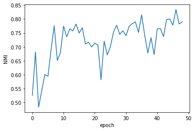

```python
plt.plot(NMI_history_acinar)
plt.xlabel('epoch')
plt.ylabel('NMI')
plt.savefig("../results/figures/NMI_acinar_cell_car.png", format = 'png', bbox_inches="tight", dpi = 200)
```

We can see that NMI increases with epoches

## Genes pseudolabels after training

```python
import umap.umap_ as umap
embedding_after_acinar = umap.UMAP(n_neighbors=5, min_dist=0.0, n_components=2,
                  metric='correlation').fit_transform(y_pred_acinar)
```

```python
embedding_after_acinar_df = pd.DataFrame(embedding_after_acinar)
embedding_after_acinar_df.columns=['UMAP1','UMAP2']
embedding_after_acinar_df["Proton"]=original
embedding_after_acinar_df["new"]=np.argmax(au_tar_acinar, axis = 1)
```

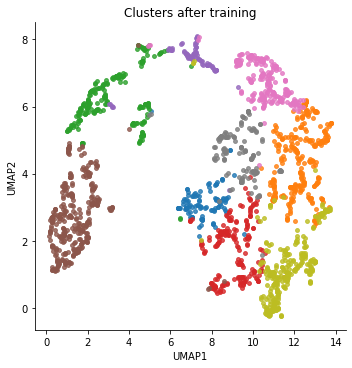

```python
f=sns.lmplot(x='UMAP1', y='UMAP2',data=embedding_after_acinar_df,hue="new",
             fit_reg=False,legend=False,scatter_kws={'s':15})
plt.title("Clusters after training")
plt.savefig("../results/figures/clusters_after_training_acinar_cell_carci.png",format = 'png', bbox_inches="tight", dpi = 200)
```

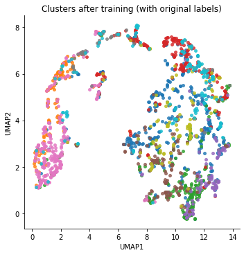

```python
f=sns.lmplot(x='UMAP1', y='UMAP2',data=embedding_after_acinar_df,hue="Proton",
             fit_reg=False,legend=False,scatter_kws={'s':15})
plt.title("Clusters after training (with original labels)")
plt.savefig("../results/figures/clusters_after_training_acinar_cell_carci_w_orig_labels.png",format = 'png', bbox_inches="tight", dpi = 200)
```

**We can clearly see that the genes gets re-clustering to different positions (or neighborhoods) upon training forming new clusters**

```python
# interactive UMAP
import umap.umap_ as umap
embedding_after_acinar = umap.UMAP(n_neighbors=5, min_dist=0.0, n_components=2,
                      metric='correlation').fit(y_pred_acinar)
import umap.plot
hover_data = pd.DataFrame(
{'cluster':np.argmax(au_tar_acinar, axis = 1),
 'Gene': genes,
 'Index': range(dataset.shape[0])})
p = umap.plot.interactive(embedding_after_acinar, labels= np.argmax(au_tar_acinar, axis = 1), hover_data=hover_data, point_size=5,color_key_cmap='Paired', background='black')
umap.plot.show(p)
```

## Sample Genes Spatial Patterns within clusters

Here we're selecting genes from different clusters and visualizing the spatial expression patterns of them to investigate if the model was able to cluster genes according to their spatial expression

### Sample 1

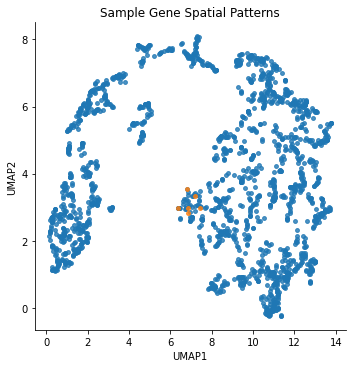

```python
goi = ['SETBP1','NDRG1','COL5A2','PDE3A','LAMC3','PAMR1']
goi_index = []
for i in goi:
    goi_index.append(genes.index(i))
embedding_after_acinar_df["goi"] = 0
embedding_after_acinar_df["goi"].iloc[goi_index] = 1
f=sns.lmplot(x='UMAP1', y='UMAP2',data=embedding_after_acinar_df, hue="goi",
             fit_reg=False,legend=False,scatter_kws={'s':15})
plt.title("Sample Gene Spatial Patterns")
plt.savefig("../results/figures/sample_goi_1.png", format = 'png', bbox_inches="tight", dpi = 200)
```

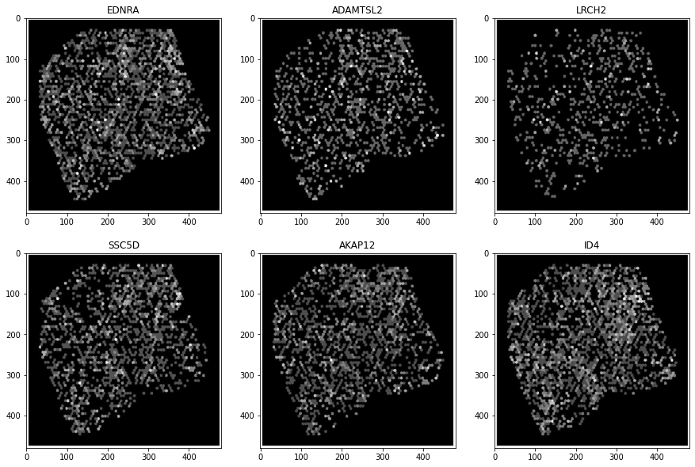

```python
plt.figure(figsize=(15, 10))
plt.subplot(2, 3, 1)
plt.imshow(Image.open("../results/GeneExpImgs/acinar_cell_carcinoma/EDNRA.jpeg"))
plt.title("EDNRA")
plt.subplot(2, 3, 2)
plt.imshow(Image.open("../results/GeneExpImgs/acinar_cell_carcinoma/ADAMTSL2.jpeg"))
plt.title("ADAMTSL2")
plt.subplot(2, 3, 3)
plt.imshow(Image.open("../results/GeneExpImgs/acinar_cell_carcinoma/LRCH2.jpeg"))
plt.title("LRCH2")
plt.subplot(2, 3, 4)
plt.imshow(Image.open("../results/GeneExpImgs/acinar_cell_carcinoma/SSC5D.jpeg"))
plt.title("SSC5D")
plt.subplot(2, 3, 5)
plt.imshow(Image.open("../results/GeneExpImgs/acinar_cell_carcinoma/AKAP12.jpeg"))
plt.title("AKAP12")
plt.subplot(2, 3, 6)
plt.imshow(Image.open("../results/GeneExpImgs/acinar_cell_carcinoma/ID4.jpeg"))
plt.title("ID4")
plt.savefig("../results/figures/sample_goi_1_images.jpeg", format = 'jpeg', bbox_inches="tight", dpi = 200)
```

### Sample 2

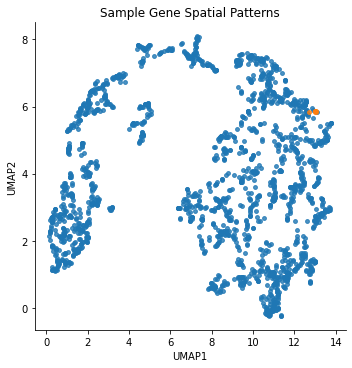

```python
goi = ['C3','WFDC2','SERPINA3','LCN2','CYBA','PIGR']
goi_index = []
for i in goi:
    goi_index.append(genes.index(i))
embedding_after_acinar_df["goi"] = 0
embedding_after_acinar_df["goi"].iloc[goi_index] = 1
f=sns.lmplot(x='UMAP1', y='UMAP2',data=embedding_after_acinar_df,hue="goi",
             fit_reg=False,legend=False,scatter_kws={'s':15})
plt.title("Sample Gene Spatial Patterns")
plt.savefig("../results/figures/sample_goi_2.png", format = 'png', bbox_inches="tight", dpi = 200)
```

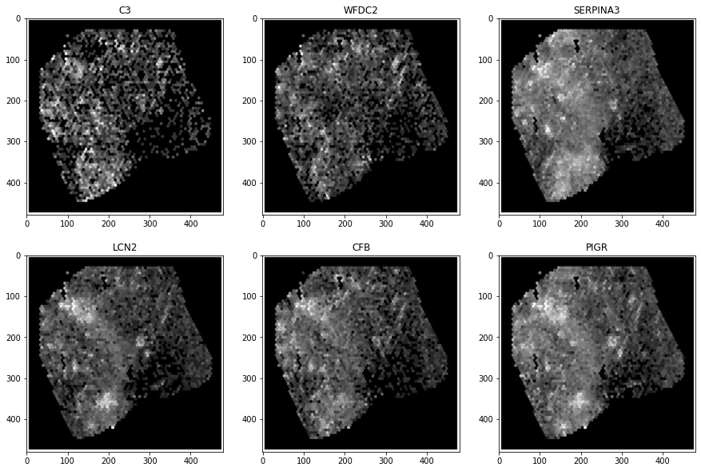

```python
plt.figure(figsize=(15, 10))
plt.subplot(2, 3, 1)
plt.imshow(Image.open("../results/GeneExpImgs/acinar_cell_carcinoma/C3.jpeg"))
plt.title("C3")
plt.subplot(2, 3, 2)
plt.imshow(Image.open("../results/GeneExpImgs/acinar_cell_carcinoma/WFDC2.jpeg"))
plt.title("WFDC2")
plt.subplot(2, 3, 3)
plt.imshow(Image.open("../results/GeneExpImgs/acinar_cell_carcinoma/SERPINA3.jpeg"))
plt.title("SERPINA3")
plt.subplot(2, 3, 4)
plt.imshow(Image.open("../results/GeneExpImgs/acinar_cell_carcinoma/LCN2.jpeg"))
plt.title("LCN2")
plt.subplot(2, 3, 5)
plt.imshow(Image.open("../results/GeneExpImgs/acinar_cell_carcinoma/CFB.jpeg"))
plt.title("CFB")
plt.subplot(2, 3, 6)
plt.imshow(Image.open("../results/GeneExpImgs/acinar_cell_carcinoma/PIGR.jpeg"))
plt.title("PIGR")
plt.savefig("../results/figures/sample_goi_2_images.jpeg", format = 'jpeg', bbox_inches="tight", dpi = 200)
```

### Sample 3

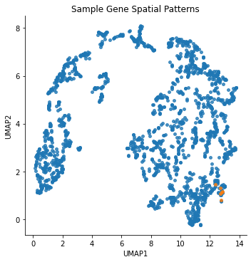

```python
goi = ['CD37','JAK3','TRAC','CD3D','CD4','FCMR']
goi_index = []
for i in goi:
    goi_index.append(genes.index(i))
embedding_after_acinar_df["goi"] = 0
embedding_after_acinar_df["goi"].iloc[goi_index] = 1
f=sns.lmplot(x='UMAP1', y='UMAP2',data=embedding_after_acinar_df,hue="goi",
             fit_reg=False,legend=False,scatter_kws={'s':15})
plt.title("Sample Gene Spatial Patterns")
plt.savefig("../results/figures/sample_goi_3.png", format = 'png', bbox_inches="tight", dpi = 200)
```

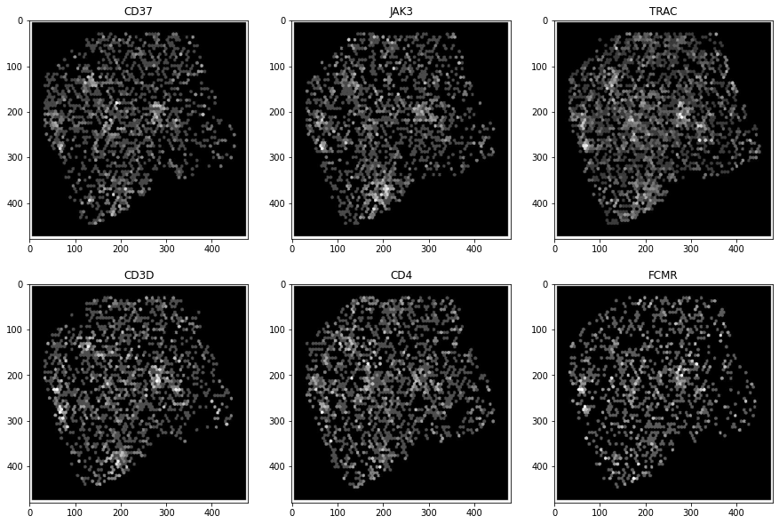

```python
plt.figure(figsize=(15, 10))
plt.subplot(2, 3, 1)
plt.imshow(Image.open("../results/GeneExpImgs/acinar_cell_carcinoma/CD37.jpeg"))
plt.title("CD37")
plt.subplot(2, 3, 2)
plt.imshow(Image.open("../results/GeneExpImgs/acinar_cell_carcinoma/JAK3.jpeg"))
plt.title("JAK3")
plt.subplot(2, 3, 3)
plt.imshow(Image.open("../results/GeneExpImgs/acinar_cell_carcinoma/TRAC.jpeg"))
plt.title("TRAC")
plt.subplot(2, 3, 4)
plt.imshow(Image.open("../results/GeneExpImgs/acinar_cell_carcinoma/CD3D.jpeg"))
plt.title("CD3D")
plt.subplot(2, 3, 5)
plt.imshow(Image.open("../results/GeneExpImgs/acinar_cell_carcinoma/CD4.jpeg"))
plt.title("CD4")
plt.subplot(2, 3, 6)
plt.imshow(Image.open("../results/GeneExpImgs/acinar_cell_carcinoma/FCMR.jpeg"))
plt.title("FCMR")
plt.savefig("../results/figures/sample_goi_3_images.jpeg", format = 'jpeg', bbox_inches="tight", dpi = 200)
```

### Sample 4

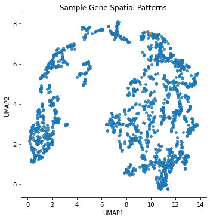

```python
goi = ['CD74','B2M','HLA-DRA']
goi_index = []
for i in goi:
    goi_index.append(genes.index(i))
embedding_after_acinar_df["goi"] = 0
embedding_after_acinar_df["goi"].iloc[goi_index] = 1
f=sns.lmplot(x='UMAP1', y='UMAP2',data=embedding_after_acinar_df,hue="goi",
             fit_reg=False,legend=False,scatter_kws={'s':15})
plt.title("Sample Gene Spatial Patterns")
plt.savefig("../results/figures/sample_goi_4.png", format = 'png', bbox_inches="tight", dpi = 200)
```

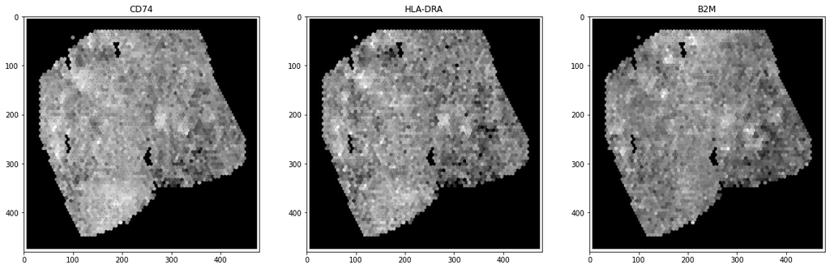

```python
plt.figure(figsize=(20, 15))
plt.subplot(1, 3, 1)
plt.imshow(Image.open("../results/GeneExpImgs/acinar_cell_carcinoma/CD74.jpeg"))
plt.title("CD74")
plt.subplot(1, 3, 2)
plt.imshow(Image.open("../results/GeneExpImgs/acinar_cell_carcinoma/HLA-DRA.jpeg"))
plt.title("HLA-DRA")
plt.subplot(1, 3, 3)
plt.imshow(Image.open("../results/GeneExpImgs/acinar_cell_carcinoma/B2M.jpeg"))
plt.title("B2M")
plt.savefig("../results/figures/sample_goi_4_images.jpeg", format = 'jpeg', bbox_inches="tight", dpi = 200)
```

**We can clearly see that genes in the same neighborhood exhibit similar expression patterns. Also, in sample 3 we note that most of those genes are T-Cell markers.**

# Saving Results

```python
torch.save(net.state_dict(), "../results/models/CoSTA_acinar_cell_carci_visium_trained_model.pth")
np.save(arr = y_pred_acinar, file =  "../results/training_results_arrays/y_pred_acinar.npy")
np.save(arr = au_tar_acinar, file = "../results/training_results_arrays/au_tar_acinar.npy")
np.save(arr = np.array(NMI_history_acinar), file = "../results/training_results_arrays/NMI_history_acinar.npy")
```